# Homework 4

Izzi Grasso Due: 4/13/2020

## Problem 1

#### Create df

```r
df <- data.frame(
  Method = c(rep(x = "MethodA", times = 6),
             rep(x = "MethodB", times = 7),
             rep(x = "MethodC", times = 5)),
  Value = c(77, 54, 67, 74, 71, 66,
            60, 41, 59, 65, 62, 64, 52,
            49, 52, 69, 47, 56)
)
```

Null hypothesis: Distributions are identical. Alt: Not null.

$\alpha$ = 0.05.

#### Kruskal Wallis

```r
kruskal.test(Value ~ Method, data = df)
```

```
    Kruskal-Wallis rank sum test

data:  Value by Method
Kruskal-Wallis chi-squared = 6.6731, df = 2, p-value = 0.03556
```

Since p < 0.05, we reject the null hypothesis at $\alpha$ = 0.05 and conclude there is a difference in efficacy of corrosion reduction methods.

#### Post-hoc

```r
pairwise.wilcox.test(df$Value, df$Method,
                 p.adjust.method = "bonferroni")
```

```
cannot compute exact p-value with ties
```

```
    Pairwise comparisons using Wilcoxon rank sum test

data:  df$Value and df$Method

        MethodA MethodB
MethodB 0.066   -
MethodC 0.156   1.000

P value adjustment method: bonferroni
```

## Problem 2

#### Data

```r
  Polluted <- c(21.3, 18.7, 23.0, 17.1, 16.8, 20.9, 19.7)
  Unpolluted  <-  c(14.2, 18.3, 17.2, 18.4, 20.0)
```

#### Test for homogeneity

Null hypothesis: $\sigma_1^2$ = $\sigma_2^2$ Alternative hyp: $\sigma_1^2$ $\neq$ $\sigma_2^2$

```r
var.test(Polluted, Unpolluted)
```

```
    F test to compare two variances

data:  Polluted and Unpolluted
F = 1.112, num df = 6, denom df = 4, p-value = 0.9618
alternative hypothesis: true ratio of variances is not equal to 1
95 percent confidence interval:
 0.120901 6.924380
sample estimates:
ratio of variances
          1.111964
```

At $\alpha$ = 0.05, we fail to reject null hypothesis.

#### Check for normality (Shapiro)

Null Hypothesis: normally distributed Alternative Hyp: Not normally distributed

```r
shapiro.test(Polluted)
```

```
    Shapiro-Wilk normality test

data:  Polluted
W = 0.95574, p-value = 0.7815
```

```r
shapiro.test(Unpolluted)
```

```
    Shapiro-Wilk normality test

data:  Unpolluted
W = 0.92311, p-value = 0.5502
```

Fail to reject null hypothesis. Assumption of normality holds.

#### Pooled t-test

Null Hypothesis: $\mu_1$ = $\mu_2$ Althernative Hyp: $\mu_1$ > $\mu_2$

```r
t.test(Polluted, Unpolluted, alternative = "greater", var.equal = TRUE)
```

```
    Two Sample t-test

data:  Polluted and Unpolluted
t = 1.5505, df = 10, p-value = 0.07603
alternative hypothesis: true difference in means is greater than 0
95 percent confidence interval:
 -0.3417755        Inf
sample estimates:
mean of x mean of y
 19.64286  17.62000
```

We fail to reject the null hypothesis at $\alpha$ = 0.05. There is not significant evidence that the true fluoride concentration for livestock grazing is higher in the polluted region than the unpolluted region.

## Problem 3

#### Data

```r
Day1 <- c(5.0, 4.8, 5.1, 5.1, 4.8, 5.1, 4.8, 4.8, 5.0, 5.2, 4.9, 4.9, 5.0)
Day2 <- c(5.8, 4.7, 4.7, 4.9, 5.1, 4.9, 5.4, 5.3, 5.3, 4.8, 5.7, 5.1, 5.7)
```

#### Test for homogeneity

Null Hypothesis: $\sigma_1^2$ = $\sigma_2^2$ Alternative Hyp: $\sigma_1^2$ < $\sigma_2^2$

```r
var.test(Day1, Day2, alternative = "less", conf.level = .99)
```

```
    F test to compare two variances

data:  Day1 and Day2
F = 0.12987, num df = 12, denom df = 12,
p-value = 0.0006359
alternative hypothesis: true ratio of variances is less than 1
99 percent confidence interval:
 0.0000000 0.5396439
sample estimates:
ratio of variances
         0.1298701
```

At $\alpha$ = 0.01, we reject the null hypothesis. There is significant evidence that the variability of the process is greater on the second day than on the first.

## Problem 4

#### Data

```r
Men <- c(5, 10, 2, 0, 6, 4, 5, 15)
Women <- c(8, 9, 3, 5, 0, 4, 15)
```

#### Test for normality (shapiro)

Null Hypothesis: normally distributed Alternative Hyp: Not normally distributed

```r
shapiro.test(Men)
```

```
    Shapiro-Wilk normality test

data:  Men
W = 0.92306, p-value = 0.4552
```

```r
shapiro.test(Women)
```

```
    Shapiro-Wilk normality test

data:  Women
W = 0.95919, p-value = 0.8117
```

Fail to reject null hypothesis. Assumption of normality holds.

#### Test for homogeneity

Null Hypothesis: $\sigma_1^2$ = $\sigma_2^2$ Alternative Hyp: $\sigma_1^2$ $\neq$ $\sigma_2^2$

```r
var.test(Men, Women)
```

```
    F test to compare two variances

data:  Men and Women
F = 0.92555, num df = 7, denom df = 6,
p-value = 0.9082
alternative hypothesis: true ratio of variances is not equal to 1
95 percent confidence interval:
 0.1625059 4.7375059
sample estimates:
ratio of variances
         0.9255478
```

Fail to reject null hypothesis. We can assume homogeneity.

#### Two sample t-test

```r
t.test(Men, Women, alternative = "two.sided", paired = FALSE, var.equal = TRUE, conf.level = 0.95)
```

```
    Two Sample t-test

data:  Men and Women
t = -0.16566, df = 13, p-value = 0.871
alternative hypothesis: true difference in means is not equal to 0
95 percent confidence interval:
 -5.766671  4.945242
sample estimates:
mean of x mean of y
 5.875000  6.285714
```

At $\alpha$ = 0.05, we fail to reject the null hypothesis. There is not significant evidence that there is a difference in sick days between men and women.

## Problem 5

#### Data frame

```r
df3 <- data.frame(
  F1 = c(58, 29, 37, 40, 44, 37, 49, 49, 38),
  F2 = c(68, 67, 69, 58, 62, 48, 62, 76, 66),
  F3 = c(96, 90, 90, 103, 100, 91, 100, 114, 94),
  F4 = c(101, 110, 90, 103, 100, 91, 100, 114, 94),
  F5 = c(124, 114, 111, 113, 114, 102, 114, 112, 103)
)
```

#### Test for normality

```r
shapiro.test(df3$F1)
```

```
    Shapiro-Wilk normality test

data:  df3$F1
W = 0.95931, p-value = 0.7911
```

```r
shapiro.test(df3$F2)
```

```
    Shapiro-Wilk normality test

data:  df3$F2
W = 0.94681, p-value = 0.6551
```

```r
shapiro.test(df3$F3)
```

```
    Shapiro-Wilk normality test

data:  df3$F3
W = 0.88471, p-value = 0.1759
```

```r
shapiro.test(df3$F4)
```

```
    Shapiro-Wilk normality test

data:  df3$F4
W = 0.94141, p-value = 0.5968
```

```r
shapiro.test(df3$F5)
```

```
    Shapiro-Wilk normality test

data:  df3$F5
W = 0.8834, p-value = 0.1705
```

Fail to reject null hypothesis. Normality assumption holds.

#### ANOVA

Null hypothesis: $\mu_1$ = $\mu_2$ = .. = $\mu_5$ Alternative hyp: Not null hypothesis

```r
df4 <- df3 %>% gather(Fertilizer, Value)
model <- aov(Value ~ Fertilizer, df4)
summary(model)
```

```
            Df Sum Sq Mean Sq F value Pr(>F)
Fertilizer   4  30253    7563     124 <2e-16
Residuals   40   2439      61

Fertilizer  ***
Residuals
---
Signif. codes:
0 ‘***’ 0.001 ‘**’ 0.01 ‘*’ 0.05 ‘.’ 0.1 ‘ ’ 1
```

At $\alpha$ = 0.01, we reject the null hypothesis. There is evidence that there is difference in yield by fertilizer.

#### Residual analysis

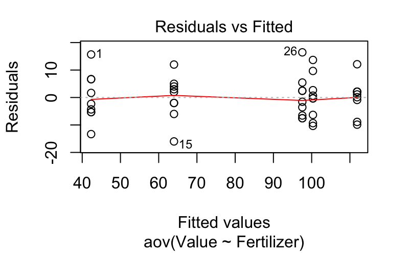

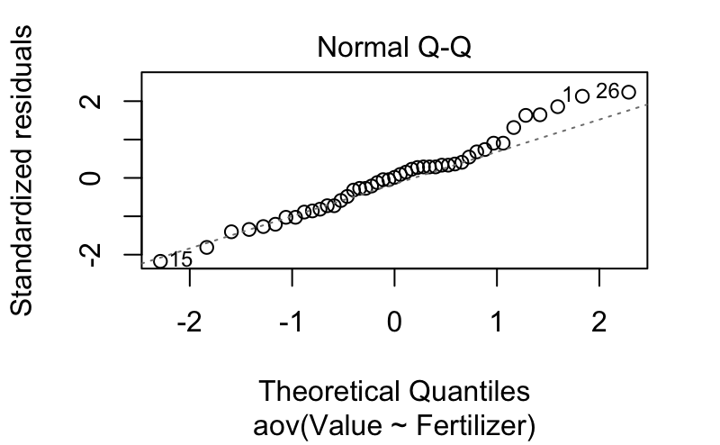

```
hat values (leverages) are all = 0.1111111
 and there are no factor predictors; no plot no. 5
```

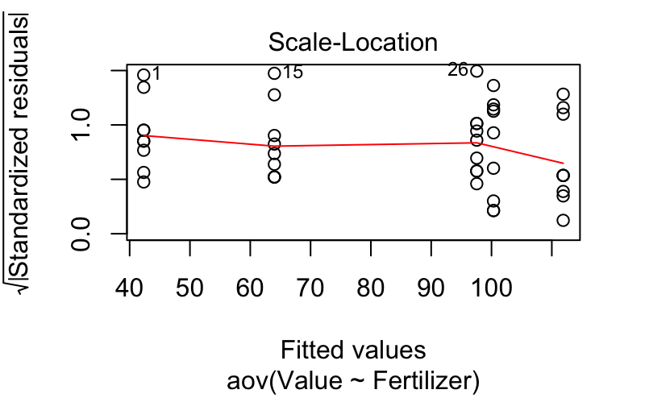

```r
plot(model)
```

Normality assumption holds, and homogeneity assumption holds.

#### Tukey test

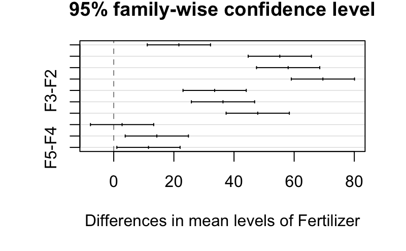

```r
plot(TukeyHSD(model))
```

All yields are different from others except F4-F3. F5 produces the largest yield.

#### Kruskal Wallis

Null hypothesis: $\mu_1$ = $\mu_2$ = .. = $\mu_5$ Alternative hyp: Not null hypothesis

```r
kruskal.test(Value ~ as.factor(Fertilizer), data = df4)
```

```
    Kruskal-Wallis rank sum test

data:  Value by as.factor(Fertilizer)
Kruskal-Wallis chi-squared = 37.545, df =
4, p-value = 1.391e-07
```

At $\alpha$ = 0.01, we reject the null hypothesis. There is evidence that there is a difference of yield by fertilizer type.

#### Post hoc

```r
pairwise.wilcox.test(df4$Value, df4$Fertilizer,
                 p.adjust.method = "bonferroni")
```

[output not shown]

```
    Pairwise comparisons using Wilcoxon rank sum test

data:  df4$Value and df4$Fertilizer

   F1     F2     F3     F4
F2 0.0124 -      -      -
F3 0.0040 0.0040 -      -
F4 0.0040 0.0041 1.0000 -
F5 0.0040 0.0040 0.0444 0.0768

P value adjustment method: bonferroni
```

At $\alpha$ = 0.01, F3-F4, F4-F5, F3-F5, and F1-F2 do not have a significant difference.

## Problem 6

#### Data

```r
x <- c(47, 62, 65, 70, 75, 78, 95, 100, 120, 118)
y <- c(38, 62, 60, 67, 84, 79, 93, 104, 117, 150)
df5 <- data.frame(
  X = x,
  Y = y
)
```

#### Plot

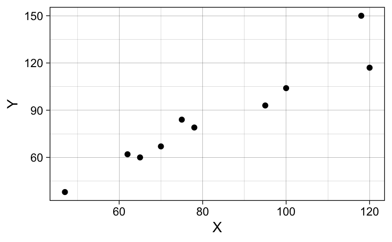

```r
ggplot(df5, aes(x = X, y = Y)) +
  geom_point() +
  theme_linedraw()
```

Data looks linear, correlation analysis is reasonable.

#### Spearman Rank

Null hypothesis: $\rho$ = 0 Alternative hyp: $\rho$ $\neq$ 0

```r
cor.test(x, y, method = "spearman")
```

```
    Spearman's rank correlation rho

data:  x and y
S = 6, p-value < 2.2e-16
alternative hypothesis: true rho is not equal to 0
sample estimates:
      rho
0.9636364
```

At $\alpha$ = 0.05 we reject the null hypothesis. There is a strong positive correlation between x and y.